# Stat 432 regression

Pengyu Cheng, Bing Liang, Siyu Lai

12/15/2018

# Load Data

```r
# Load Training data
data.train = read.csv('TrainData_reg.csv')
data.test = read.csv('TestData_reg.csv')
n = which(colnames(data.train) == 'ARRIVAL_DELAY')
X.train = data.train[, -n]
y.train = data.train[, n]
X.test = data.test[, -n]
y.test = data.test[, n]
```

# Ridge regression

## Fitting (Cross validation with 10-folds to select lambda)

```r
library(glmnet)
ridge = cv.glmnet(data.matrix(X.train), y.train, nfolds = 10, alpha = 0)
```

## Select best lambda

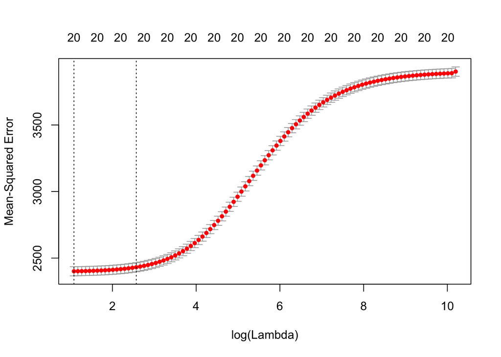

```r
plot(ridge)
```

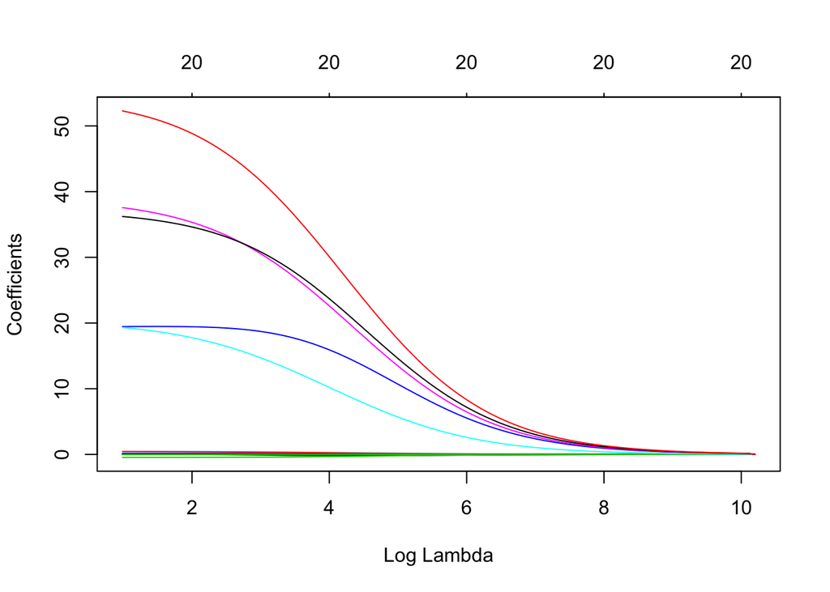

```r
plot(ridge$glmnet.fit, "lambda")
```

```r
best.lambda = ridge$lambda.1se
```

We use the second one as that lambda is larger and the mse is about the same as the lambda.min. This can reduce overfitting.

## Coefficient:

```r
coef(ridge, s = best.lambda)
```

```
## 21 x 1 sparse Matrix of class "dgCMatrix"
##                                 1
## (Intercept)         -9.0383078290
## MONTH               -0.0411177502
## DAY                 -0.0211625381
## DAY_OF_WEEK         -0.4277764633
## AIRLINE              0.1538289808
## FLIGHT_NUMBER       -0.0003147601
## TAIL_NUMBER         -0.0002050596
## ORIGIN_AIRPORT       0.0684704928
## DESTINATION_AIRPORT -0.0020512248
## SCHEDULED_DEPARTURE -0.0053521777
## DEPARTURE_TIME       0.0090617116
## TAXI_OUT             0.4076177178
## DISTANCE             0.0001777008
## WHEELS_ON           -0.0091734330
## TAXI_IN              0.3790355425
## SCHEDULED_ARRIVAL    0.0064888185
## AIR_SYSTEM_DELAY    19.1893083338
## SECURITY_DELAY      16.2361996975
## AIRLINE_DELAY       32.9995094072
## LATE_AIRCRAFT_DELAY 32.8357149240
## WEATHER_DELAY       45.3162778852
```

## Predict:

```r
newX.ridge <- model.matrix(data.test$ARRIVAL_DELAY~.,data=data.test)
newX.ridge <- newX.ridge[,-1]
ridge.pred <- round(predict(ridge, s = best.lambda, newx = newX.ridge))
(ridge.mse  <- mean((ridge.pred - y.test)^2))
```

```
## [1] 2574.877
```

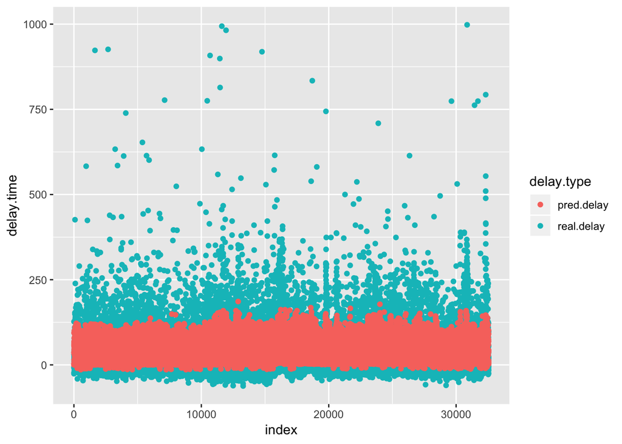

```r
library(ggplot2)
library(tidyr)
test_data <-
  data.frame(
    real.delay = y.test,
    pred.delay = as.numeric(ridge.pred),
    index = c(1:length(y.test))
  )
test_data %>%
    gather(delay.type, delay.time, real.delay, pred.delay) %>%
    ggplot(aes(x=index, y=delay.time, colour=delay.type))+ geom_point()
```

# Lasso Regression

## Fitting (Cross validation with 10-folds to select lambda)

```r
lasso = cv.glmnet(data.matrix(X.train), y.train, nfolds = 10, alpha = 1)
```

## Select best lambda

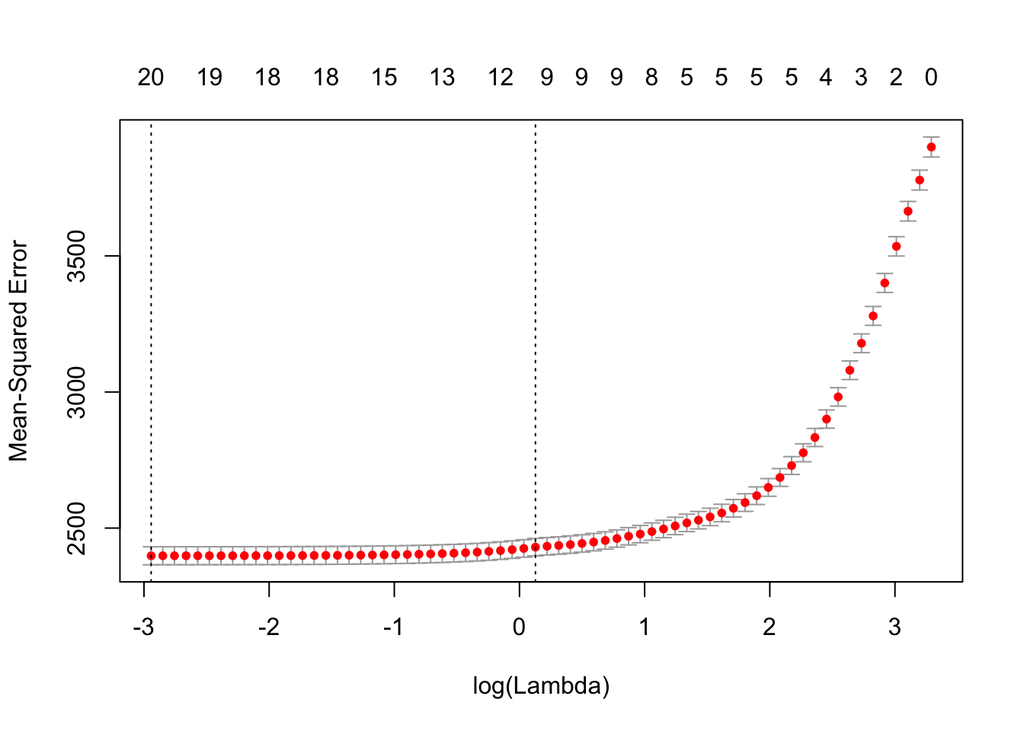

```r
plot(lasso)
```

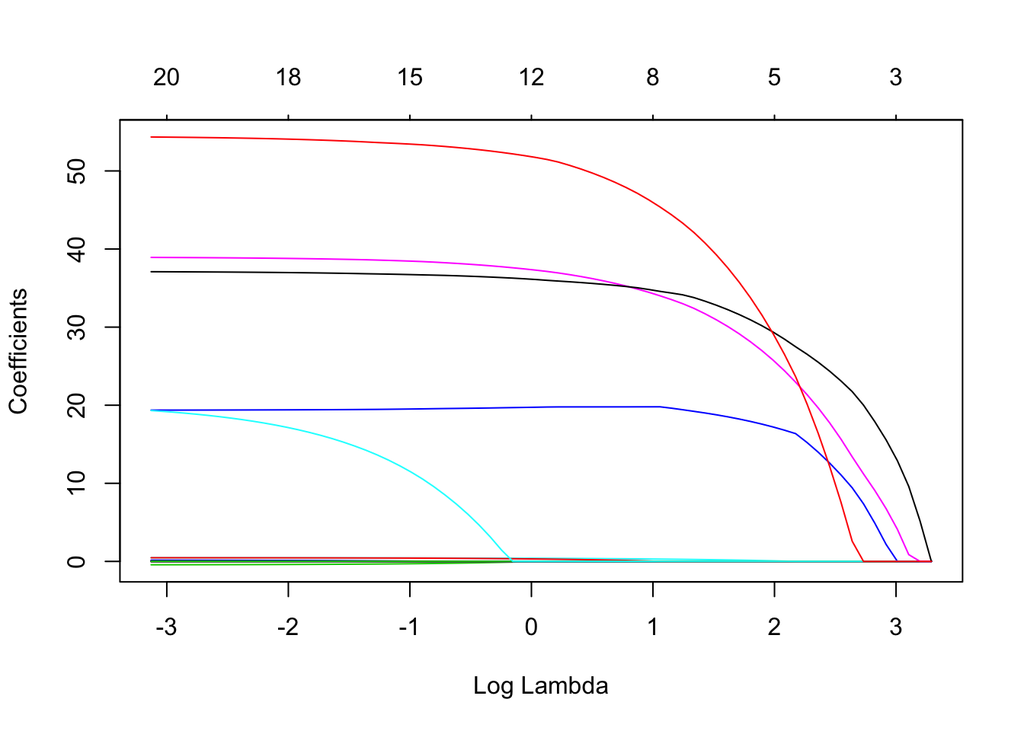

```r
plot(lasso$glmnet.fit, "lambda")
```

```r
best.lambda = lasso$lambda.1se
```

- We use the second one as that lambda is larger and the mse is about the same as the lambda.min. This can reduce overfitting.

## Coefficient:

```r
coef(lasso, s = best.lambda)
```

```
## 21 x 1 sparse Matrix of class "dgCMatrix"
##                                 1
## (Intercept)         -5.3743659448
## MONTH                .
## DAY                  .
## DAY_OF_WEEK          .
## AIRLINE              .
## FLIGHT_NUMBER        .
## TAIL_NUMBER          .
## ORIGIN_AIRPORT       0.0046775557
## DESTINATION_AIRPORT  .
## SCHEDULED_DEPARTURE -0.0003037487
## DEPARTURE_TIME       0.0040816310
## TAXI_OUT             0.3904496271
## DISTANCE             .
## WHEELS_ON           -0.0077108518
## TAXI_IN              0.2953726122
## SCHEDULED_ARRIVAL    0.0047350304
## AIR_SYSTEM_DELAY    19.7685129041
## SECURITY_DELAY       .
## AIRLINE_DELAY       37.1312279987
## LATE_AIRCRAFT_DELAY 35.9932401467
## WEATHER_DELAY       51.4698740885
```

- Month, day, airline and some other attributes have been removed by Lasso.

## Predict:

```r
newX.lasso <- model.matrix(data.test$ARRIVAL_DELAY~.,data=data.test)
newX.lasso <- newX.lasso[,-1]
lasso.pred <- predict(lasso, s = best.lambda, newx = newX.lasso)
(lasso.mse  <- mean((lasso.pred - y.test)^2))
```

```
## [1] 2573.015
```

- Comparing the mse between the Ridge Regression and the Lasso Regression, Lasso did a better job. Why? Because Lasso has built in feature eliminiation function (L1-norm penalty term) but Ridge does not. Ridge can only shrink the coefficients close to zero. So when it comes to fit the testing data, mse of ridge will be larger as ridge model in our case tends to overfit the training set compared to lasso.

## Visualize the prediciton

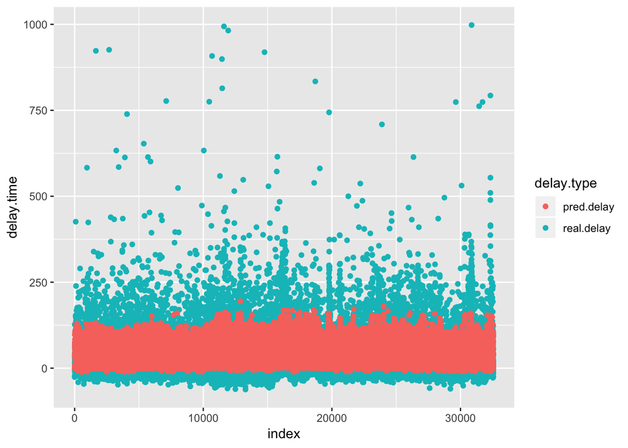

```r
library(ggplot2)
library(tidyr)
test_data <-
  data.frame(
    real.delay = y.test,
    pred.delay = as.numeric(lasso.pred),
    index = c(1:length(y.test))
  )
test_data %>%
    gather(delay.type, delay.time, real.delay, pred.delay) %>%
    ggplot(aes(x=index, y=delay.time, colour=delay.type))+ geom_point()
```

# Neural Network

The Neural Net in library neuralNetwork does not work very efficiently for our large scaled data. We ended up using TensorFlow for R, which released recently. By using TensorFlow, we can dump our model by give a model_dir and retrain the saved model. In addition, we can visulize the computation graph of the model in TensorBorad.

```r
library(tfestimators)
response <- function() "ARRIVAL_DELAY"
features <- function() setdiff(names(X.train), response())
```

- construct feature columns

```r
feature_columns <- feature_columns(
  column_numeric(features())
)
```

- construct classifier
  - We use Adagrad optimizer and RELU activation function with dropout rate = 10% to suppress the overfitting of the model. As the dataset is not that large and Neural Network can be scaled for large dataset, we only use 0.1 as dropout rate. There are two layers in the network with 16 neurons and 8 neurous. The last layer is activated by logistic function by default.

```r
# construct DNN regressor
model_dir = 'DNN_Regessor_final.md'
regressor <- dnn_regressor(hidden_units=c(16, 8),
                           feature_columns=feature_columns,
                           model_dir = model_dir,
                           label_dimension = 1L,
                           weight_column = NULL,
                           optimizer = "Adagrad",
                           activation_fn = "relu",
                           dropout = 0.1,
                           input_layer_partitioner = NULL,
                           config = NULL)
```

```r
input_fn_delay <- function(data, epoches) {
  input_fn(data,
           features = features(),
           response = response(),
           batch_size = 128,
           num_epochs = epoches)
}
```

## Train: Using 4 epochs (number of epochs has large effect on the model overfitting)

```r
tfestimators::train(regressor, input_fn = input_fn_delay(data.train, 4))
```

## Predict:

```r
predictions <- predict(regressor, input_fn = input_fn_delay(data.test, 1))
y.pred = as.numeric(unlist(predictions))
(mse = sum((y.pred - y.test)^2) / length(y.pred))
```

```
## [1] 1323.472
```

- MSE from Neural Network is better than the lasso and ridge.

## Visualize the prediciton

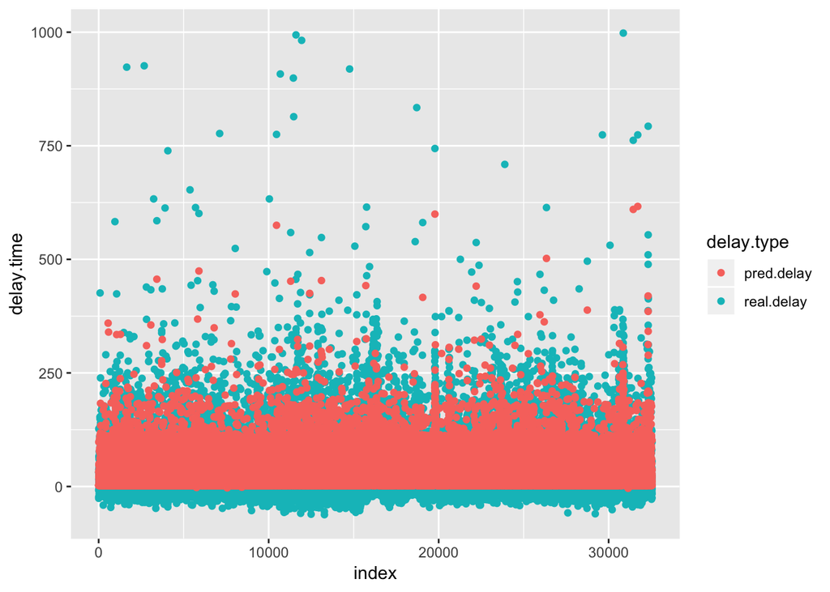

```r
test_data <-
  data.frame(
    real.delay = y.test,
    pred.delay = y.pred,
    index = c(1:length(y.test))
  )
test_data %>%
    gather(delay.type, delay.time, real.delay, pred.delay) %>%
    ggplot(aes(x=index, y=delay.time, colour=delay.type))+ geom_point()
```